# Salary Prediction EDA

```python
'''This script loads, explores, and visualizes the salary prediction datasets'''


__author__ = 'DSDJ Team'
__email__ = 'info@datasciencedreamjob..com'
__website__ = 'www.datasciencedreamjob.com'

__copyright__ = 'Copyright 2018, Data Science Dream Job LLC'
```

```python
import numpy as np
import pandas as pd
import matplotlib.pyplot as plt
import seaborn as sns
% matplotlib inline
```

### Load the data

```python
# Read in files and print the information
train_feature_df = pd.read_csv('data/train_features.csv')
train_target_df = pd.read_csv('data/train_salaries.csv')
test_feature_df = pd.read_csv('data/test_features.csv')
```

### Examine the data

```python
train_feature_df.head(10)
```

|  | jobId | companyId | jobType | degree | major | industry | yearsExperience | milesFromMetropolis |
| --- | --- | --- | --- | --- | --- | --- | --- | --- |
| 0 | JOB1362684407687 | COMP37 | CFO | MASTERS | MATH | HEALTH | 10 | 83 |
| 1 | JOB1362684407688 | COMP19 | CEO | HIGH_SCHOOL | NONE | WEB | 3 | 73 |
| 2 | JOB1362684407689 | COMP52 | VICE_PRESIDENT | DOCTORAL | PHYSICS | HEALTH | 10 | 38 |
| 3 | JOB1362684407690 | COMP38 | MANAGER | DOCTORAL | CHEMISTRY | AUTO | 8 | 17 |
| 4 | JOB1362684407691 | COMP7 | VICE_PRESIDENT | BACHELORS | PHYSICS | FINANCE | 8 | 16 |
| 5 | JOB1362684407692 | COMP15 | MANAGER | DOCTORAL | COMPSCI | FINANCE | 2 | 31 |
| 6 | JOB1362684407693 | COMP15 | CFO | NONE | NONE | HEALTH | 23 | 24 |
| 7 | JOB1362684407694 | COMP24 | JUNIOR | BACHELORS | CHEMISTRY | EDUCATION | 9 | 70 |
| 8 | JOB1362684407695 | COMP20 | JANITOR | HIGH_SCHOOL | NONE | EDUCATION | 1 | 54 |
| 9 | JOB1362684407696 | COMP41 | VICE_PRESIDENT | BACHELORS | CHEMISTRY | AUTO | 17 | 68 |

```python
test_feature_df.head(10)
```

|  | jobId | companyId | jobType | degree | major | industry | yearsExperience | milesFromMetropolis |
| --- | --- | --- | --- | --- | --- | --- | --- | --- |
| 0 | JOB1362685407687 | COMP33 | MANAGER | HIGH_SCHOOL | NONE | HEALTH | 22 | 73 |
| 1 | JOB1362685407688 | COMP13 | JUNIOR | NONE | NONE | AUTO | 20 | 47 |
| 2 | JOB1362685407689 | COMP10 | CTO | MASTERS | BIOLOGY | HEALTH | 17 | 9 |
| 3 | JOB1362685407690 | COMP21 | MANAGER | HIGH_SCHOOL | NONE | OIL | 14 | 96 |
| 4 | JOB1362685407691 | COMP36 | JUNIOR | DOCTORAL | BIOLOGY | OIL | 10 | 44 |
| 5 | JOB1362685407692 | COMP40 | CTO | MASTERS | COMPSCI | FINANCE | 6 | 23 |
| 6 | JOB1362685407693 | COMP32 | SENIOR | MASTERS | COMPSCI | SERVICE | 6 | 32 |
| 7 | JOB1362685407694 | COMP11 | CEO | BACHELORS | BIOLOGY | SERVICE | 9 | 73 |
| 8 | JOB1362685407695 | COMP39 | MANAGER | DOCTORAL | PHYSICS | HEALTH | 6 | 78 |
| 9 | JOB1362685407696 | COMP22 | VICE_PRESIDENT | NONE | NONE | AUTO | 23 | 97 |

```python
train_target_df.head(10)
```

|  | jobId | salary |
| --- | --- | --- |
| 0 | JOB1362684407687 | 130 |
| 1 | JOB1362684407688 | 101 |
| 2 | JOB1362684407689 | 137 |
| 3 | JOB1362684407690 | 142 |
| 4 | JOB1362684407691 | 163 |
| 5 | JOB1362684407692 | 113 |
| 6 | JOB1362684407693 | 178 |
| 7 | JOB1362684407694 | 73 |
| 8 | JOB1362684407695 | 31 |
| 9 | JOB1362684407696 | 104 |

### Use .info() to see length and dtypes

```python
train_feature_df.info()
```

```
<class 'pandas.core.frame.DataFrame'>
RangeIndex: 1000000 entries, 0 to 999999
Data columns (total 8 columns):
jobId                  1000000 non-null object
companyId              1000000 non-null object
jobType                1000000 non-null object
degree                 1000000 non-null object
major                  1000000 non-null object
industry               1000000 non-null object
yearsExperience        1000000 non-null int64
milesFromMetropolis    1000000 non-null int64
dtypes: int64(2), object(6)
memory usage: 61.0+ MB
```

```python
train_target_df.info()
```

```
<class 'pandas.core.frame.DataFrame'>
RangeIndex: 1000000 entries, 0 to 999999
Data columns (total 2 columns):
jobId     1000000 non-null object
salary    1000000 non-null int64
dtypes: int64(1), object(1)
memory usage: 15.3+ MB
```

```python
test_feature_df.info()
```

```
<class 'pandas.core.frame.DataFrame'>
RangeIndex: 1000000 entries, 0 to 999999
Data columns (total 8 columns):
jobId                  1000000 non-null object
companyId              1000000 non-null object
jobType                1000000 non-null object
degree                 1000000 non-null object
major                  1000000 non-null object
industry               1000000 non-null object
yearsExperience        1000000 non-null int64
milesFromMetropolis    1000000 non-null int64
dtypes: int64(2), object(6)
memory usage: 61.0+ MB
```

### Check for duplicates

```python
train_feature_df.duplicated().sum()
```

```
0
```

```python
train_target_df.duplicated().sum()
```

```
0
```

```python
test_feature_df.duplicated().sum()
```

```
0
```

### Identify numerical and categorical variables

```python
train_feature_df.columns
```

```
Index(['jobId', 'companyId', 'jobType', 'degree', 'major', 'industry',
       'yearsExperience', 'milesFromMetropolis'],
      dtype='object')
```

```python
numeric_cols = ['yearsExperience', 'milesFromMetropolis']
```

```python
categorical_cols = ['jobId', 'companyId', 'jobType', 'degree', 'major', 'industry']
```

### Summarize numerical and categorical variables separately

```python
train_feature_df.describe(include = [np.number])
```

|  | yearsExperience | milesFromMetropolis |
| --- | --- | --- |
| count | 1000000.000000 | 1000000.000000 |
| mean | 11.992386 | 49.529260 |
| std | 7.212391 | 28.877733 |
| min | 0.000000 | 0.000000 |
| 25% | 6.000000 | 25.000000 |
| 50% | 12.000000 | 50.000000 |
| 75% | 18.000000 | 75.000000 |
| max | 24.000000 | 99.000000 |

```python
train_feature_df.describe(include = ['O'])
```

|  | jobId | companyId | jobType | degree | major | industry |
| --- | --- | --- | --- | --- | --- | --- |
| count | 1000000 | 1000000 | 1000000 | 1000000 | 1000000 | 1000000 |
| unique | 1000000 | 63 | 8 | 5 | 9 | 7 |
| top | JOB1362684829113 | COMP39 | SENIOR | HIGH_SCHOOL | NONE | WEB |
| freq | 1 | 16193 | 125886 | 236976 | 532355 | 143206 |

### Merge features and targets into single df (optional: delete original dfs)

```python
# Merge the features and salaries on jobId, delete original file to save memory
train_df = pd.merge(train_feature_df, train_target_df, on='jobId')
```

```python
#del train_feature_df
#del train_target_df
```

```python
train_df.info()
```

```
<class 'pandas.core.frame.DataFrame'>
Int64Index: 1000000 entries, 0 to 999999
Data columns (total 9 columns):
jobId                  1000000 non-null object
companyId              1000000 non-null object
jobType                1000000 non-null object
degree                 1000000 non-null object
major                  1000000 non-null object
industry               1000000 non-null object
yearsExperience        1000000 non-null int64
milesFromMetropolis    1000000 non-null int64
salary                 1000000 non-null int64
dtypes: int64(3), object(6)
memory usage: 76.3+ MB
```

```python
train_df.head()
```

|  | jobId | companyId | jobType | degree | major | industry | yearsExperience | milesFromMetropolis | salary |
| --- | --- | --- | --- | --- | --- | --- | --- | --- | --- |
| 0 | JOB1362684407687 | COMP37 | CFO | MASTERS | MATH | HEALTH | 10 | 83 | 130 |
| 1 | JOB1362684407688 | COMP19 | CEO | HIGH_SCHOOL | NONE | WEB | 3 | 73 | 101 |
| 2 | JOB1362684407689 | COMP52 | VICE_PRESIDENT | DOCTORAL | PHYSICS | HEALTH | 10 | 38 | 137 |
| 3 | JOB1362684407690 | COMP38 | MANAGER | DOCTORAL | CHEMISTRY | AUTO | 8 | 17 | 142 |
| 4 | JOB1362684407691 | COMP7 | VICE_PRESIDENT | BACHELORS | PHYSICS | FINANCE | 8 | 16 | 163 |

### Visualize target variable (salary)

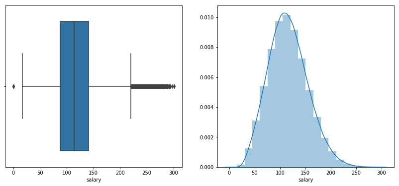

```python
plt.figure(figsize = (14, 6))
plt.subplot(1,2,1)
sns.boxplot(train_df.salary)
plt.subplot(1,2,2)
sns.distplot(train_df.salary, bins=20)
plt.show()
```

### Use IQR rule to identify potential outliers

```python
stat = train_df.salary.describe()
print(stat)
IQR = stat['75%'] - stat['25%']
upper = stat['75%'] + 1.5 * IQR
lower = stat['25%'] - 1.5 * IQR
print('The upper and lower bounds for suspected outliers are {} and {}.'.format(upper, lower))
```

```
count    1000000.000000
mean         116.061818
std           38.717936
min            0.000000
25%           88.000000
50%          114.000000
75%          141.000000
max          301.000000
Name: salary, dtype: float64
The upper and lower bounds for suspected outliers are 220.5 and 8.5.
```

### Examine potential outliers

```python
#check potential outlier below lower bound
train_df[train_df.salary < 8.5]
```

|  | jobId | companyId | jobType | degree | major | industry | yearsExperience | milesFromMetropolis | salary |
| --- | --- | --- | --- | --- | --- | --- | --- | --- | --- |
| 30559 | JOB1362684438246 | COMP44 | JUNIOR | DOCTORAL | MATH | AUTO | 11 | 7 | 0 |
| 495984 | JOB1362684903671 | COMP34 | JUNIOR | NONE | NONE | OIL | 1 | 25 | 0 |
| 652076 | JOB1362685059763 | COMP25 | CTO | HIGH_SCHOOL | NONE | AUTO | 6 | 60 | 0 |
| 816129 | JOB1362685223816 | COMP42 | MANAGER | DOCTORAL | ENGINEERING | FINANCE | 18 | 6 | 0 |
| 828156 | JOB1362685235843 | COMP40 | VICE_PRESIDENT | MASTERS | ENGINEERING | WEB | 3 | 29 | 0 |

```python
#check potential outlier above upper bound
train_df.loc[train_df.salary > 222.5, 'jobType'].value_counts()
```

```
CEO               2893
CFO               1308
CTO               1298
VICE_PRESIDENT     520
MANAGER            188
SENIOR              50
JUNIOR              16
Name: jobType, dtype: int64
```

```python
# Check most suspicious potential outliers above upper bound
train_df[(train_df.salary > 222.5) & (train_df.jobType == 'JUNIOR')]
```

|  | jobId | companyId | jobType | degree | major | industry | yearsExperience | milesFromMetropolis | salary |
| --- | --- | --- | --- | --- | --- | --- | --- | --- | --- |
| 1222 | JOB1362684408909 | COMP40 | JUNIOR | MASTERS | COMPSCI | OIL | 24 | 5 | 225 |
| 27710 | JOB1362684435397 | COMP21 | JUNIOR | DOCTORAL | ENGINEERING | OIL | 24 | 3 | 246 |
| 31355 | JOB1362684439042 | COMP45 | JUNIOR | DOCTORAL | COMPSCI | FINANCE | 24 | 0 | 225 |
| 100042 | JOB1362684507729 | COMP17 | JUNIOR | DOCTORAL | BUSINESS | FINANCE | 23 | 8 | 248 |
| 160333 | JOB1362684568020 | COMP18 | JUNIOR | DOCTORAL | BUSINESS | FINANCE | 22 | 3 | 223 |
| 303778 | JOB1362684711465 | COMP51 | JUNIOR | MASTERS | ENGINEERING | WEB | 24 | 2 | 226 |
| 348354 | JOB1362684756041 | COMP56 | JUNIOR | DOCTORAL | ENGINEERING | OIL | 23 | 25 | 226 |
| 500739 | JOB1362684908426 | COMP40 | JUNIOR | DOCTORAL | ENGINEERING | OIL | 21 | 0 | 227 |
| 627534 | JOB1362685035221 | COMP5 | JUNIOR | DOCTORAL | ENGINEERING | OIL | 24 | 29 | 230 |
| 645555 | JOB1362685053242 | COMP36 | JUNIOR | DOCTORAL | BUSINESS | FINANCE | 24 | 1 | 225 |
| 685775 | JOB1362685093462 | COMP38 | JUNIOR | BACHELORS | ENGINEERING | OIL | 24 | 13 | 225 |
| 743326 | JOB1362685151013 | COMP14 | JUNIOR | DOCTORAL | BUSINESS | FINANCE | 19 | 0 | 236 |
| 787674 | JOB1362685195361 | COMP43 | JUNIOR | DOCTORAL | BUSINESS | FINANCE | 18 | 15 | 232 |
| 796956 | JOB1362685204643 | COMP30 | JUNIOR | MASTERS | BUSINESS | OIL | 24 | 2 | 228 |
| 855219 | JOB1362685262906 | COMP13 | JUNIOR | MASTERS | ENGINEERING | OIL | 22 | 26 | 225 |
| 954368 | JOB1362685362055 | COMP11 | JUNIOR | DOCTORAL | BUSINESS | OIL | 24 | 26 | 223 |

These entries with zero salary do not appear to be volunteer positions. We are confident that they are instances of missing/corrupt data and should be removed from the training set.

The high-salary potential outliers all appear to be legitimate data. Most roles are C-level executive roles and the junior positions are in industries that are well known for high salaries (oil, finance). We determine these entries to be legitimate and will not remove them.

```python
# Remove data with zero salaries
train_df = train_df[train_df.salary > 8.5]
```

```python
def plot_feature(df, col):
    '''
    Make plot for each features
    left, the distribution of samples on the feature
    right, the dependance of salary on the feature
    '''
    plt.figure(figsize = (14, 6))
    plt.subplot(1, 2, 1)
    if df[col].dtype == 'int64':
        df[col].value_counts().sort_index().plot()
    else:
        #change the categorical variable to category type and order their level by the mean salary
        #in each category
        mean = df.groupby(col)['salary'].mean()
        df[col] = df[col].astype('category')
        levels = mean.sort_values().index.tolist()
        df[col].cat.reorder_categories(levels, inplace=True)
        df[col].value_counts().plot()
    plt.xticks(rotation=45)
    plt.xlabel(col)
    plt.ylabel('Counts')
    plt.subplot(1, 2, 2)

    if df[col].dtype == 'int64' or col == 'companyId':
        #plot the mean salary for each category and fill between the (mean - std, mean + std)
        mean = df.groupby(col)['salary'].mean()
        std = df.groupby(col)['salary'].std()
        mean.plot()
        plt.fill_between(range(len(std.index)), mean.values-std.values, mean.values + std.values, \
                         alpha = 0.1)
    else:
        sns.boxplot(x = col, y = 'salary', data=df)

    plt.xticks(rotation=45)
    plt.ylabel('Salaries')
    plt.show()
```

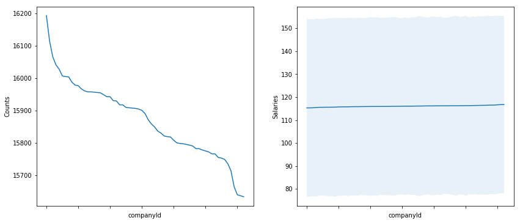

```python
plot_feature(train_df, 'companyId')
```

**The salary is weakly associated with companies.**

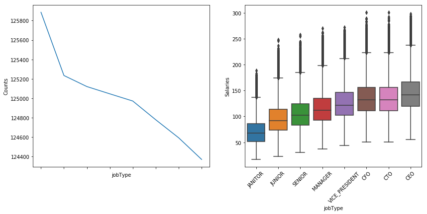

```python
plot_feature(train_df, 'jobType')
```

**There is a clear positive correlation between job type and salary.**

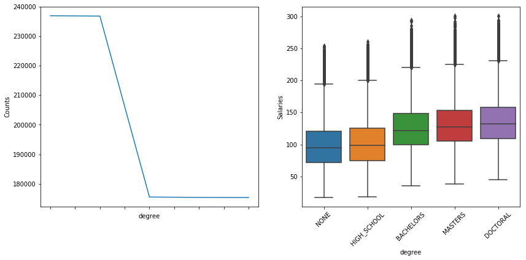

```python
plot_feature(train_df, 'degree')
```

**More advanced degrees tend to correspond to higher salaries.**

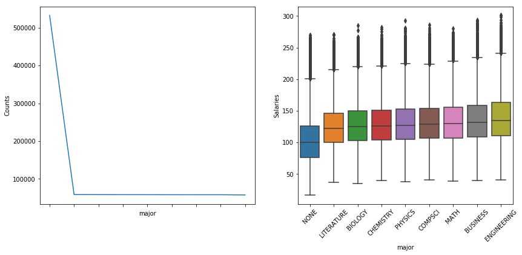

```python
plot_feature(train_df, 'major')
```

**People with majors of engineering, business and math generally have higher salaries.**

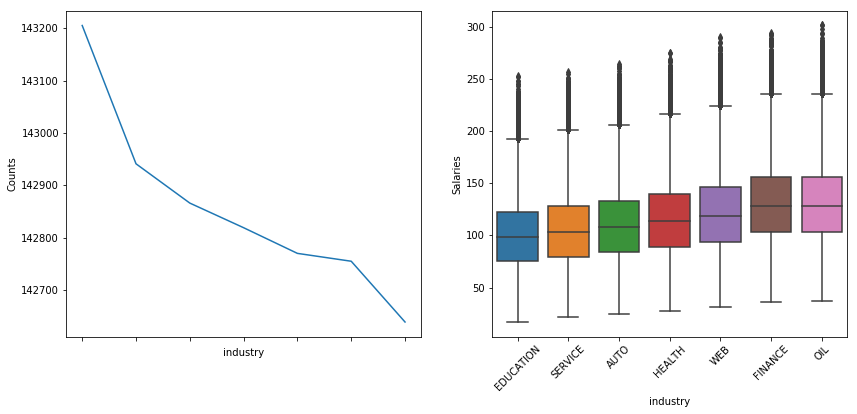

```python
plot_feature(train_df, 'industry')
```

**As for industries, oil, finance and web industries generally pay better.**

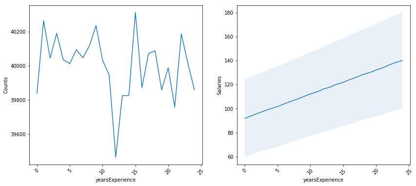

```python
plot_feature(train_df, 'yearsExperience')
```

**In general, there is a clear correlation between salary and years of experience.**

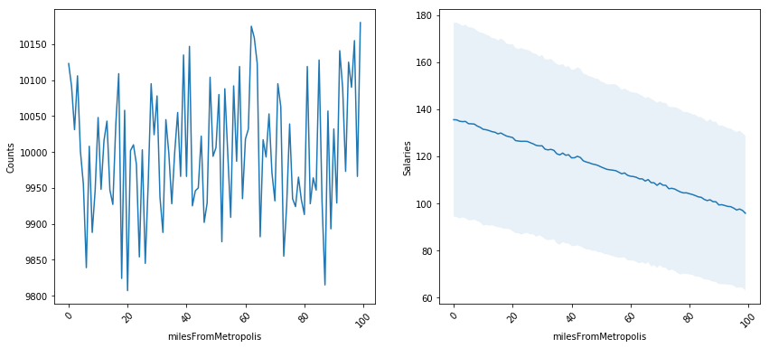

```python
plot_feature(train_df, 'milesFromMetropolis')
```

**In general, salaries decrease with the distance to metropolis.**

```python
def encode_label(df, col):
    #encode the categories using average salary for each category to replace label
    cat_dict ={}
    cats = df[col].cat.categories.tolist()
    for cat in cats:
        cat_dict[cat] = train_df[train_df[col] == cat]['salary'].mean()
    df[col] = df[col].map(cat_dict)
```

```python
for col in train_df.columns:
    if train_df[col].dtype.name == "category":
        encode_label(train_df, col)
```

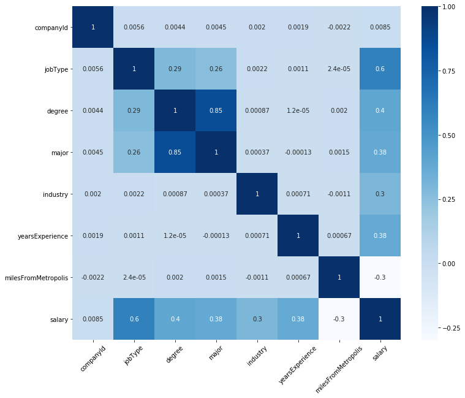

```python
# Correlations between selected features and response
# jobId is discarded because it is unique for individual
fig = plt.figure(figsize=(12, 10))
features = ['companyId', 'jobType', 'degree', 'major', 'industry', 'yearsExperience', 'milesFromMetropolis']
sns.heatmap(train_df[features + ['salary']].corr(), cmap='Blues', annot=True)
plt.xticks(rotation=45)
plt.show()
```

We see that jobType is most strongly correlated with salary, followed by degree, major, and yearsExperience.

Among the features, we see that degree and major have a strong degree of correlation and jobType has a moderate degree of correlation with both degree and major.